# Modeling and prediction for movies

## Setup

### Load packages

```r
library(ggplot2)
library(dplyr)
library(statsr)
library(GGally)
```

### Load data

```r
load("movies.Rdata")
```

## Part 1: Data

The data set is comprised of 651 randomly sampled movies produced and released before 2016. This data has 32 variables and contains a lot of information about the movie.

Many variables are categorical, like name of actors, movies, etc, which are not much useful. Variables including the link of movie reviews etc are also not useful for our analytics. Hence we will be focusing majorly on some of the important factors like Imdb scores, critics scores and audience score, also categorical variable like whether the director of the movie is an Oscar winner or not, or type of movie, and whether the casting actor or actress is an Oscar winner or not and lastly whether the movie won best picture on Oscars.

## Part 2: Research question

We all look at the IMDB rating before watching a movie, and its everywhere, on Google, Prime, Netflix etc. Thus here I will be predicting the IMDB rating of a movie based on other factors.

## Part 3: Exploratory data analysis

So generally if a movie has a good actor or actress that is Oscar winning Actor or Actress, we try to watch the movie. If the director is Oscar winning then we definitely watch the movie. Hence I will try to find whether this effects the movie rating or not. That is how far does the presence of an Oscar winning person effect the IMDB rating.

```r
count(movies,best_actor_win,best_dir_win,best_actress_win)
```

```
## # A tibble: 8 x 4
##   best_actor_win best_dir_win best_actress_win     n
##   <fct>          <fct>        <fct>            <int>
## 1 no             no           no                 480
## 2 no             no           yes                 47
## 3 no             yes          no                  26
## 4 no             yes          yes                  5
## 5 yes            no           no                  65
## 6 yes            no           yes                 16
## 7 yes            yes          no                   8
## 8 yes            yes          yes                  4
```

Another thing you might notice, is that just from winning the Oscars not all the movies can’t be scored. That is we have a lot of movies which cannot be just scored/predicted from these 3 variables.

Hence, we can see other important variables audience and critics score.

```r
summary(movies$audience_score)
```

```
##    Min. 1st Qu.  Median    Mean 3rd Qu.    Max.
##   11.00   46.00   65.00   62.36   80.00   97.00
```

```r
summary(movies$critics_score)
```

```
##    Min. 1st Qu.  Median    Mean 3rd Qu.    Max.
##    1.00   33.00   61.00   57.69   83.00  100.00
```

```r
summary(movies$imdb_rating)
```

```
##    Min. 1st Qu.  Median    Mean 3rd Qu.    Max.
##   1.900   5.900   6.600   6.493   7.300   9.000
```

Now let us plot between audience score and critics score to find a linear regression betweeen them.

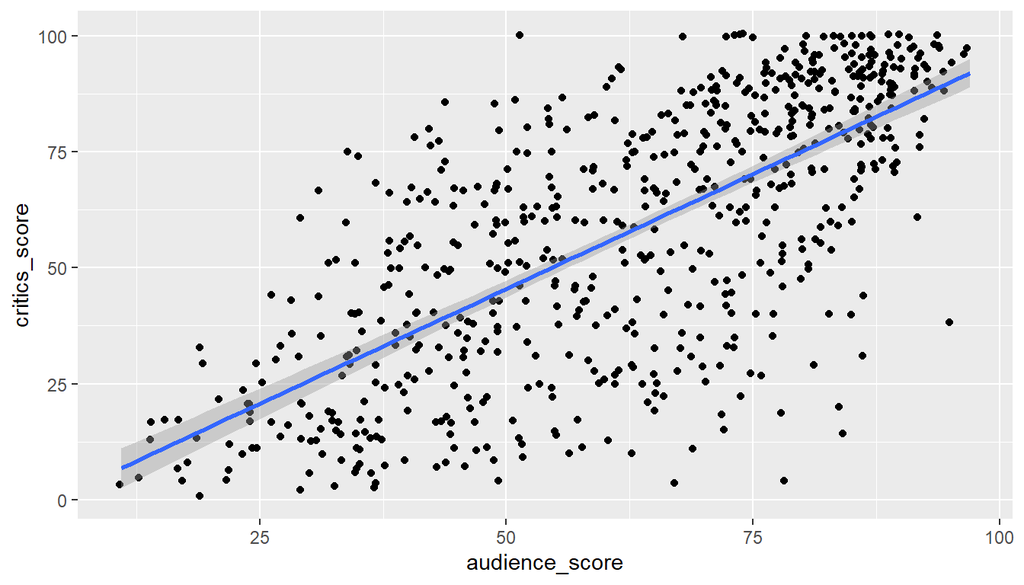

```r
ggplot(movies,aes(x=audience_score,y=critics_score))+geom_jitter()+geom_smooth(method="lm")
```

Similarly lets try for imdb rating and critics score.

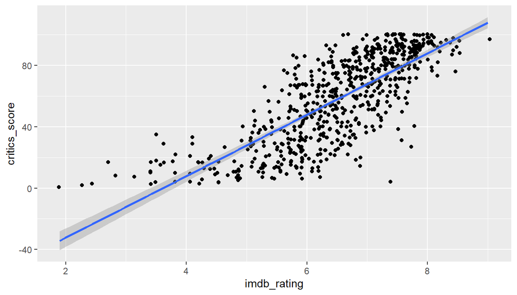

```r
ggplot(movies,aes(x=imdb_rating,y=critics_score))+geom_jitter()+geom_smooth(method="lm")
```

We can see that critics score and IMDB rating are highly correlated.

## Part 4: Modeling

I will be following a backward elimination -p value model. Here I have selected my initial model based on variables: critics_score: Critics score on Rotten Tomatoes audience_score: Audience score on Rotten Tomatoes best_actor_win best_actress_win best_dir_win

Now lets start with our model having all the variable.

```r
lr <- lm(imdb_rating ~critics_score+audience_score+
best_actor_win+best_actress_win+best_dir_win,data=movies)
summary(lr)$coefficients
```

```
##                       Estimate   Std. Error   t value      Pr(>|t|)
## (Intercept)         3.62577714 0.0626874800 57.838936 1.960534e-257
## critics_score       0.01150032 0.0009549553 12.042782  2.853313e-30
## audience_score      0.03480572 0.0013330573 26.109694 4.246665e-103
## best_actor_winyes   0.09987069 0.0554077780  1.802467  7.193867e-02
## best_actress_winyes 0.10118671 0.0617535178  1.638558  1.017930e-01
## best_dir_winyes     0.11880644 0.0782104098  1.519062  1.292370e-01
```

Hence we can remove the variable best_dir_win as it p value > .05.(Standard)

```r
lr <- lm(imdb_rating ~critics_score+audience_score+
best_actor_win+best_actress_win,data=movies)
summary(lr)$coefficients
```

```
##                       Estimate   Std. Error   t value      Pr(>|t|)
## (Intercept)         3.62413705 0.0627415822 57.762921 2.442329e-257
## critics_score       0.01162998 0.0009520949 12.215151  5.088943e-31
## audience_score      0.03481004 0.0013344027 26.086606 5.134003e-103
## best_actor_winyes   0.10738133 0.0552425614  1.943815  5.235160e-02
## best_actress_winyes 0.10720062 0.0616888210  1.737764  8.272893e-02
```

Similarly we can delete best_actress_win as its p value is greater than 0.05.

```r
lr <- lm(imdb_rating ~critics_score+audience_score+
best_actor_win,data=movies)
summary(lr)$coefficients
```

```
##                     Estimate   Std. Error   t value      Pr(>|t|)
## (Intercept)       3.63203374 0.0626744075 57.950827 2.568050e-258
## critics_score     0.01171892 0.0009522012 12.307191  2.003972e-31
## audience_score    0.03476197 0.0013361968 26.015609 1.143132e-102
## best_actor_winyes 0.12016517 0.0548359439  2.191358  2.878172e-02
```

Now we can say this our final model with the equtation as IMDB Rating = 3.63 + 0.011*Critics_score + 0.03*audience_score + 0.12*best_actor_win

Note if best_actor_win is yes we will put 1 else 0.

This is the confidence interval of the model

```r
confint(lr)
```

```
##                         2.5 %     97.5 %
## (Intercept)       3.508963932 3.75510354
## critics_score     0.009849144 0.01358870
## audience_score    0.032138167 0.03738578
## best_actor_winyes 0.012487265 0.22784308
```

## Part 5: Prediction

The Founder movie had IMDB 7.2, Critics Score 72, Audience Score as 82 and the actor Micheal Keaton, was nominated but has not won best actor in Oscars, but awards in various other categories.

```r
newdata <- data.frame(critics_score=72,
                      audience_score=82,
                      best_actor_win='no')
```

After framing the data as dataframe, we will now predict the IMDB rating through the predict function.

```r
predict(lr,newdata)
```

```
##        1
## 7.326278
```

```r
predict(lr, newdata, interval = "confidence")
```

```
##        fit      lwr     upr
## 1 7.326278 7.270706 7.38185
```

```r
predict(lr, newdata, interval = "prediction",level=0.95)
```

```
##        fit      lwr      upr
## 1 7.326278 6.364491 8.288064
```

As you can see the IMDB value predicted is 7.32 while the actual value is 7.2 . Hence we can say the model is pretty accurate even though the confidence interval is short.

## Part 6: Conclusion

We can Observe that IMDB rating can be predicted majorly on basis of Audience Score, Critics Score and whether the Actor in the movie is an Oscar Winner or not. We also considered other variables but removed them from our model as they were not able to satisfy our significance level(p-value).

We predicted our model and tested it against the movie The Founder. It starred Micheal Keaton, and was scored 72 by critics and 82 by audience at rotten tomatoes. Micheal Keaton was nominated for Best Actor at Oscars, but not able to win it.

We can say that our model is good but not perfect as the prediction level is very high. This maybe due to the fact that the data had more categorical data and not much numerical data.